# Minado de texto a partir de pdfs

Jose Antonio Gonzalez Doñas

11 de mayo de 2018

## *Text mining* a partir de archivos PDF

Vamos a explicar en este documento, paso a paso, cómo realizar minería de datos a partir de la información contenida en documentos pdf. Los pasos a seguir serán:

1. Obtener textos de los ficheros pdf
2. Preprocesamiento de textos
3. Minería de texto
4. Análisis gráfico de los resultados

**Antes de comenzar, indicar que este trabajo ha sido realizado en entorno Linux, porque destacaré los posibles problemas y particularidades que peuda surgir en este caso, y de igual manera obviaré los que puedan surgir en otros sitemas operativos, aunque se conoce que dependiendo del caso, una u otras librerías darán problema.**

## 1. Obtener textos de los ficheros pdf

Partiendo de un conjunto de *pdfs*, preferiblemente contenidos dentro de un directorio, vamos a extraer su contenido para poder manipularlo posteriormente.

Para ello, tenemos que instalar y cargar la librería **tm** (cuyo nombre viene de *text mining*), así como **Rcampdf** y **pdftools**, que será necesario posteriormente:

```r
library(tm)
library(Rcampdf)
library(pdftools)
```

Por cierto, para la instalación de **pdftools** en linux, es posible la instalación prevía de algún paquete en el sistema operativo (en mi caso he tenido que instsalar libpoppler-cpp-dev)

A continuación, definimos el directorio donde se encuentran dichos pdfs, mediante el comando apropiado (el directorio cambiará dependiendo de cada caso, como es de esperar). En mi caso, como he situado los pdfs dentro del propio proyecto de R, uso la ruta relativa, que es más corta y simple:

```r
directorio.pdfs <- file.path("./", "pdfs")
dir(directorio.pdfs)
```

```
##  [1] "16122013_Edition22_DN.pdf"
##  [2] "2015_1 Spring.pdf"
##  [3] "2017-facts-and-figures.pdf"
##  [4] "489013a.pdf"
##  [5] "alzheimers-disease.pdf"
##  [6] "Alzheimers in the press.pdf"
##  [7] "Alznews11.pdf"
##  [8] "Fall-2013-News-and-Events.pdf"
##  [9] "fmw-publicaciones-amyloid-targeted-therapeutics-in-alzheimers-disease.pdf"
## [10] "medsci-05-00029-v2.pdf"
## [11] "msj.20165.pdf"
## [12] "news.161207.thesci.pdf"
## [13] "newsletter-sept16.pdf"
## [14] "News+Release+Kalgene+Biomanufacturing+and+Clinical+Trials_EN.pdf"
## [15] "preventing_alzheimers_disease_0.pdf"
## [16] "US_biotech_Cognition_Therapeutics_testsr’s_drug_in_Australia_The_Australian.pdf"
## [17] "Vidoni_FINAL.pdf"
```

A continuación, podemos leer el contenido de los ficheros pdf, e introducirlo en una variable:

```r
list.pdfs <- DirSource(directorio.pdfs)
pdfs <- Corpus(DirSource(directorio.pdfs))
Rpdf <- readPDF(control = list(text = "-layout"))
docs <- Corpus(URISource(list.pdfs), readerControl = list(reader = Rpdf))
```

[output not shown]

```
## Warning in mapply(function(elem, id) readerControl$reader(elem,
## readerControl$language, : longer argument not a multiple of length of
## shorter
```

Puede que obtengamos algunos avisos tras ejecutar estos comandos, pero podemos obviarlos.

Veamos qué tenemos ahora mismo en nuestra variable docs:

```r
summary(docs)
```

```
##                             Length Class             Mode
## 16122013_Edition22_DN.pdf   2      PlainTextDocument list
## 2015_1 Spring.pdf           2      PlainTextDocument list
## 2017-facts-and-figures.pdf  2      PlainTextDocument list
## 489013a.pdf                 2      PlainTextDocument list
## alzheimers-disease.pdf      2      PlainTextDocument list
## Alzheimers in the press.pdf 2      PlainTextDocument list
## 16122013_Edition22_DN.pdf   2      PlainTextDocument list
## 2015_1 Spring.pdf           2      PlainTextDocument list
## 2017-facts-and-figures.pdf  2      PlainTextDocument list
## 489013a.pdf                 2      PlainTextDocument list
## alzheimers-disease.pdf      2      PlainTextDocument list
## Alzheimers in the press.pdf 2      PlainTextDocument list
## 16122013_Edition22_DN.pdf   2      PlainTextDocument list
## 2015_1 Spring.pdf           2      PlainTextDocument list
## 2017-facts-and-figures.pdf  2      PlainTextDocument list
## 489013a.pdf                 2      PlainTextDocument list
## alzheimers-disease.pdf      2      PlainTextDocument list
```

En este punto, tenemos nuestros ficheros pdf en modo texto plano en una estructura de datos especial llamada **VCorpus** que a su vez es de tipo Corpus con la particularidad de que es volátil, es decir, está totalmente almacenado en memoria, y por lo tanto todo cambio que le hagamos se realizará solo en memoria, lo que significa que no habrá persistencia de los mismos tras terminar y dichos cambios se perderán al terminar de trabajar con R. Además, podemos acceder a sus elementos como si fuera una lista:

```r
class(docs)
```

```
## [1] "VCorpus" "Corpus"
```

```r
mode(docs)
```

```
## [1] "list"
```

Sin entrar en muchos detalles, un Corpus es una colección de documentos que contienen texto (en lenguaje natural). Es usado por el paquete tm.

## 2. Preprocesamiento de textos

Antes de nada, podemos inspeccionar alguno de los documentos para tener conocimiento de qué tenemos entre manos y qué podemos encontrarnos. Por ejemplo, la segunda página del primer pdf tiene como contenido el siguiente texto este documento en total tiene 9 páginas, pero mostrarlas todas hace que este documento explicativo se agrande demasiado):

```r
docs[1][["16122013_Edition22_DN.pdf"]][["content"]][2]
```

```
## [1] "EDITORIAL\nHello Dementia News readers,\nSeasons greetings! The past fortnight has been    Alzheimer’s Australia CEO Glenn Rees AM\na big one for dementia on the global stage.       welcomed the response by global health\nMost significant was the G8 Dementia Summit       ministers to invest …
```

que como podemos ver, está formado texto en inglés y por supuesto contiene todo tipo de signos de puntuación, retornos de carro, enlaces a internet, tabuladores, valores numéricos, etc.

Ahora empezaríamos con un proceso totalmente iterativo en el que poco a poco, iríamos eliminando términos no interesante, transformando palabras, etc hasta quedarnos con un conjunto de palabras realmente significativas para cada documento.

Empezaremos eliminando algunos caracteres mediante un bucle que que aplique esta transformación a todos los documentos haciendo sustituciones mediante función gsub que sustituye todas las apariciones del patrón indicado por un espacio en blanco, es decir, por lo que indiquemos como segundo parámetro:

```r
for (j in seq(docs)){
  docs[[j]] <- gsub("/"," ",docs[[j]])
  docs[[j]] <- gsub("@"," ",docs[[j]])
  docs[[j]] <- gsub("\\|", " ", docs[[j]])
}

docs[[1]][2]
```

```
## [1] "EDITORIAL\nHello Dementia News readers,\nSeasons greetings! The past fortnight has been    Alzheimer’s Australia CEO Glenn Rees AM\na big one for dementia on the global stage.       welcomed the response by global health\nMost significant was the G8 Dementia Summit       ministers to invest …
```

Para continuar con el preprocesado, usaremos además una librería llamada **SnowballC** que nos permitirá eliminar palabras poco significativas, como artículos, determinantes, así como códigos que puedan aparecer en los textos debido a la transformación de pdf a texto:

```r
library (SnowballC)
```

Esta librería contiene un listado de palabras, según el idioma, a eliminar. Por ejemplo, para el idioma en el que están escritos estos documentos, que es el inglés, las palabras a eliminar, llamadas *stopwords*, son:

```r
stopwords()
```

```
##   [1] "i"          "me"         "my"         "myself"     "we"
##   [6] "our"        "ours"       "ourselves"  "you"        "your"
##  [11] "yours"      "yourself"   "yourselves" "he"         "him"
##  [16] "his"        "himself"    "she"        "her"        "hers"
##  [21] "herself"    "it"         "its"        "itself"     "they"
##  [26] "them"       "their"      "theirs"     "themselves" "what"
##  [31] "which"      "who"        "whom"       "this"       "that"
##  [36] "these"      "those"      "am"         "is"         "are"
##  [41] "was"        "were"       "be"         "been"       "being"
##  [46] "have"       "has"        "had"        "having"     "do"
##  [51] "does"       "did"        "doing"      "would"      "should"
##  [56] "could"      "ought"      "i'm"        "you're"     "he's"
##  [61] "she's"      "it's"       "we're"      "they're"    "i've"
##  [66] "you've"     "we've"      "they've"    "i'd"        "you'd"
##  [71] "he'd"       "she'd"      "we'd"       "they'd"     "i'll"
```

[output cut: 20 more lines]

Si quisieramos añadir más palabras o eliminarlas, tan sólo tendríamos que manipular este conjunto de palabras como cualquier otro vector. En principio, si usamos este conjunto de palabras tal cual, la transformación a aplicar a los documentos sería:

```r
docs <- tm_map(docs,tolower)
docs <- tm_map(docs, removeWords, stopwords())
```

No obstante, previamente hemos todas las palabras a minúsculas, ya que esta función de sustitución es sensible a mayúsculas.

Como se puede ver, en este caso en lugar de un bucle for, hemos hecho uso de la función tm_map, que al estilo de las funciones de la familia apply, aplica la función removeWords a todos los documentos.

Nuestro texto de referencia, tras este paso se ha convertido en:

```r
 docs[[1]][2]
```

```
## [1] "editorial\nhello dementia news readers,\nseasons greetings!  past fortnight      alzheimer’s australia ceo glenn rees \n big one  dementia   global stage.       welcomed  response  global health\n significant   g8 dementia summit       ministers  invest  dementia research \n london,  brought…
```

Continuamos con el preprocesamiento, eliminando números, signos de puntuación, y espacios en blanco consecutivos:

```r
docs <- tm_map(docs,removeNumbers)
docs <- tm_map(docs,removePunctuation)
docs <- tm_map(docs, stripWhitespace)
docs[[1]][2]
```

```
## [1] "editorial hello dementia news readers seasons greetings past fortnight alzheimer’s australia ceo glenn rees big one dementia global stage welcomed response global health significant g dementia summit ministers invest dementia research london brought together health said “ question dementia o…
```

En este punto, el texto parece bastante limpio, al menos comparado con el original. Pero no vamos a dejarlo aún así: se ve que hay algunos símbolos extraños, guiones, apóstrofes… continuaremos preprocesando todavía.

En cuanto a símbolos, vamos a eliminar ‘–’, ‘•’, y ’“’ que son los que puedo ver a simple vista

```r
docs <- tm_map(docs, removeWords, c("–", "•", "\""))
docs <- tm_map(docs, stripWhitespace)
docs[[1]][2]
```

```
## [1] "editorial hello dementia news readers seasons greetings past fortnight alzheimer’s australia ceo glenn rees big one dementia global stage welcomed response global health significant g dementia summit ministers invest dementia research london brought together health said “ question dementia o…
```

Como se ve que no ha funcionado del todo, podríamos aplicar la función gsub, que de forma similar al **removePunctuation()** permite eliminar signos de puntuación mediante un comando muy simple:

```r
for (j in seq(docs)){
  docs[[j]] <- gsub('[[:punct:]]'," ",docs[[j]])
}
docs <- tm_map(docs, stripWhitespace)
docs[[1]][2]
```

```
## [1] "editorial hello dementia news readers seasons greetings past fortnight alzheimer s australia ceo glenn rees big one dementia global stage welcomed response global health significant g dementia summit ministers invest dementia research london brought together health said question dementia one…
```

Que si parece haber funcionado.

Un concepto muy interesante es el del *stemming*, que es convertir todas las palabras con raíz común a una sola, por ejemplo, palabras como response, responsive, responsible, etc serán convertidas a respons. No es la palabra original, pero para nuestro análisis es idóneo ya que hace que palabras que representan el mismo concepto tan solo estén representadas por una palabra. El resultado de aplicar la fución *stemDocument* nos deja los documentos en un estado casi ideal para comenzar con el minado en si mismo:

```r
docs <- tm_map(docs, stemDocument)
docs[[1]][2]
```

```
## [1] "editori hello dementia news reader season greet past fortnight alzheim s australia ceo glenn ree big one dementia global stage welcom respons global health signific g dementia summit minist invest dementia research london brought togeth health said question dementia one minist uk franc germa…
```

Como se ve que la eliminación de números realizada antes no ha sido efectiva del todo, pruebo con de otra forma, mediante la expresión regular apropiada. El restuldado, como se ve, es más efectivo:

```r
for (j in seq(docs)){
  docs[[j]] <- gsub('[0-9]'," ",docs[[j]])
}
docs <- tm_map(docs, stripWhitespace)
docs[[1]][2]
```

```
## [1] "editori hello dementia news reader season greet past fortnight alzheim s australia ceo glenn ree big one dementia global stage welcom respons global health signific g dementia summit minist invest dementia research london brought togeth health said question dementia one minist uk franc germa…
```

Por otro lado me doy cuenta de que hay, con cierta frecuencia, palabras de una sola letra o dos, que sin duda provienen de las transformaciones anteriores (se repite mucho ‘g’, ‘s’, por ejemplo). Las vamos a eliminar también, ya que no aportarán nada:

```r
for (j in seq(docs)){
  docs[[j]] <- gsub('\\b[A-Za-z]{1,2}\\b'," ",docs[[j]])
}
docs <- tm_map(docs, stripWhitespace)
docs[[1]][2]
```

```
## [1] "editori hello dementia news reader season greet past fortnight alzheim australia ceo glenn ree big one dementia global stage welcom respons global health signific dementia summit minist invest dementia research london brought togeth health said question dementia one minist franc germani ital…
```

En este punto, parece que el estado es perfecto para comenzar con la minería de texto como tal.

## 3. Minería de texto

Lo primero que haremos para comenzar con la minería en si misma, es obtener la matriz de términos de documentos, que nos da, para cada documento, la aparición o no de una determinada palabra. Previamente, convertimos a texto plano (**PlainTextDocument**):

```r
docsPlainText <- tm_map(docs, PlainTextDocument)
dtm <- DocumentTermMatrix(docsPlainText)
dtm
```

```
## <<DocumentTermMatrix (documents: 17, terms: 5175)>>
## Non-/sparse entries: 23122/64853
## Sparsity           : 74%
## Maximal term length: 57
## Weighting          : term frequency (tf)
```

```r
class(dtm)
```

```
## [1] "DocumentTermMatrix"    "simple_triplet_matrix"
```

Podemos figurarnos mejor qué contiene esta estructura con el comando **str**:

```r
str(dtm)
```

```
## List of 6
##  $ i       : int [1:23122] 1 1 1 1 1 1 1 1 1 1 ...
##  $ j       : int [1:23122] 9 10 16 25 33 39 41 42 43 46 ...
##  $ v       : num [1:23122] 2 3 1 1 1 3 1 1 2 2 ...
##  $ nrow    : int 17
##  $ ncol    : int 5175
##  $ dimnames:List of 2
##   ..$ Docs : chr [1:17] "character(0)" "character(0)" "character(0)" "character(0)" ...
##   ..$ Terms: chr [1:5175] "aachen" "aaic" "aarp" "abandon" ...
##  - attr(*, "class")= chr [1:2] "DocumentTermMatrix" "simple_triplet_matrix"
##  - attr(*, "weighting")= chr [1:2] "term frequency" "tf"
```

Es decir, tenemos 17 filas, una por documento, y 5175 columnas, una por término, los cuales a su vez son cadenas de caracteres, esto es, palabras. Además, podemos ver con qué frecuencia paarece cada palabra (suma de los valores de las columnas):

```r
freq <- colSums(as.matrix(dtm))
length(freq)
```

```
## [1] 5175
```

```r
ord <- order(freq)
```

A partir del vector ordenado por frecuencias, podemos ver los términos más frecuentes:

```r
tail(freq[ord])
```

```
##    peopl  caregiv     care   diseas dementia  alzheim
##     1204     1245     1650     2150     2998     4249
```

```r
noSparseTerms <- removeSparseTerms(dtm, 0.1)
noSparseTermsFreq <- colSums(as.matrix(noSparseTerms))
length(noSparseTermsFreq)
```

```
## [1] 73
```

```r
noSparseTermsFreqOrd <- order(noSparseTermsFreq)
tail(noSparseTermsFreq[noSparseTermsFreqOrd])
```

```
##      age    peopl     care   diseas dementia  alzheim
##     1061     1204     1650     2150     2998     4249
```

Si visualizamos los 73 términos resultantes tras eliminar los dispersos:

```r
noSparseTermsFreq
```

```
##    affect       age     allow      also   alzheim      base     brain
##       108      1061        48       311      4249       153       888
##       can      care    clinic    cognit   current  dementia   develop
##       312      1650       267       700       134      2998       446
##    differ    diseas      drug     earli    effect      evid     first
##       296      2150       313       138       265       174       104
##     given    higher  identifi    improv    includ   increas      just
##        78       169       240       127       295       349        61
##    latest     level      like      make       may    measur    member
##        22       149       214       126       452       111       104
##    memori     might      much    nation      need       new       one
##       282        47        69       362       191       380       353
##      part     peopl   perform     plaqu   present   prevent   protein
##        67      1204        59        98        53       190       196
##   publish    recent  research    result      risk  scientif scientist
##        78        95       707       245       677        69        59
##       see       set      show  signific      slow     studi   suggest
##       114        82       125       101        96       967       122
##   symptom    target treatment       two   univers       use   whether
##       315        81       255       194        62       659       116
##      will      work      year
##       349       144       523
```

Hay términos que deberían unificarse como uno solo. En este caso, solo se da esto en un caso: *scientif* y *scientist*, que podríamos cambiar por science, de forma que el concepto quede unificado. Para hacer esto, el proceso sería sustituir ambos términos por science en todos los documentos. Ademñas, las palabras can, just, one, see, set, two y use no me parecen muy intresantes, así que las eliminaremos de los documentos originales:

```r
for (j in seq(docs)){
  docs[[j]] <- gsub("scientif", "science", docs[[j]])
  docs[[j]] <- gsub("scientist", "science", docs[[j]])
}

docs <- tm_map(docs, removeWords, c("can", "just", "one", "see", "set", "two" , "use"))
```

Y ahora, tendríamos que repetir todo el proceso posterior:

```r
docsPlainText <- tm_map(docs, PlainTextDocument)
dtm <- DocumentTermMatrix(docsPlainText)
noSparseTerms <- removeSparseTerms(dtm, 0.1)
noSparseTermsFreq <- colSums(as.matrix(noSparseTerms))
noSparseTermsFreq
```

```
##    affect       age     allow      also   alzheim      base     brain
##       108      1061        48       311      4249       153       888
##      care    clinic    cognit   current  dementia   develop    differ
##      1650       267       700       134      2998       446       296
##    diseas      drug     earli    effect      evid     first     given
##      2150       313       138       265       174       104        78
##    higher  identifi    improv    includ   increas    latest     level
##       169       240       127       295       349        22       149
##      like      make       may    measur    member    memori     might
##       214       126       452       111       104       282        47
##      much    nation      need       new      part     peopl   perform
##        69       362       191       380        67      1204        59
##     plaqu   present   prevent   protein   publish    recent  research
##        98        53       190       196        78        95       707
##    result      risk   science      show  signific      slow     studi
##       245       677       128       125       101        96       967
##   suggest   symptom    target treatment   univers   whether      will
##       122       315        81       255        62       116       349
##      work      year
##       144       523
```

Donde vemos que ahora aparece science donde antes aparecían dos términos muy relacionados, haciendo referencia precisamente al concepto ciencia.

## 4. Análisis gráfico de los resultados

Una vez tenemos los datos que nos interesan, vamos a manipularlos para interpertarlos gráficamente, lo cual es nos dará una visión global muy fácil de interpretar,

Por ejemplo, podemos visualizar gracias a ggplot la frecuencia de los términos más importantes (solo los que tienen una frecuencia superior a por ejemplo, 150)

```r
freqTerms <- findFreqTerms(noSparseTerms, lowfreq=150)
freqTerms
```

```
##  [1] "age"       "also"      "alzheim"   "base"      "brain"
##  [6] "care"      "clinic"    "cognit"    "dementia"  "develop"
## [11] "differ"    "diseas"    "drug"      "effect"    "evid"
## [16] "higher"    "identifi"  "includ"    "increas"   "like"
## [21] "may"       "memori"    "nation"    "need"      "new"
## [26] "peopl"     "prevent"   "protein"   "research"  "result"
## [31] "risk"      "studi"     "symptom"   "treatment" "will"
## [36] "year"
```

También podemos almacenar en un *data frame* los datos:

```r
wf <- data.frame(word=names(noSparseTermsFreq), freq=noSparseTermsFreq)
wf
```

```
##                word freq
## affect       affect  108
## age             age 1061
## allow         allow   48
## also           also  311
## alzheim     alzheim 4249
## base           base  153
## brain         brain  888
## care           care 1650
## clinic       clinic  267
## cognit       cognit  700
## current     current  134
## dementia   dementia 2998
## develop     develop  446
## differ       differ  296
## diseas       diseas 2150
## drug           drug  313
## earli         earli  138
## effect       effect  265
## evid           evid  174
## first         first  104
## given         given   78
## higher       higher  169
## identifi   identifi  240
## improv       improv  127
## includ       includ  295
## increas     increas  349
## latest       latest   22
## level         level  149
## like           like  214
## make           make  126
## may             may  452
## measur       measur  111
## member       member  104
## memori       memori  282
## might         might   47
## much           much   69
## nation       nation  362
## need           need  191
## new             new  380
```

[output cut: 11 more lines]

```
## risk           risk  677
## science     science  128
## show           show  125
## signific   signific  101
## slow           slow   96
## studi         studi  967
## suggest     suggest  122
## symptom     symptom  315
## target       target   81
## treatment treatment  255
## univers     univers   62
## whether     whether  116
## will           will  349
## work           work  144
## year           year  523
```

lo cual nos permite a continuación, usar la libreria **ggplot**:

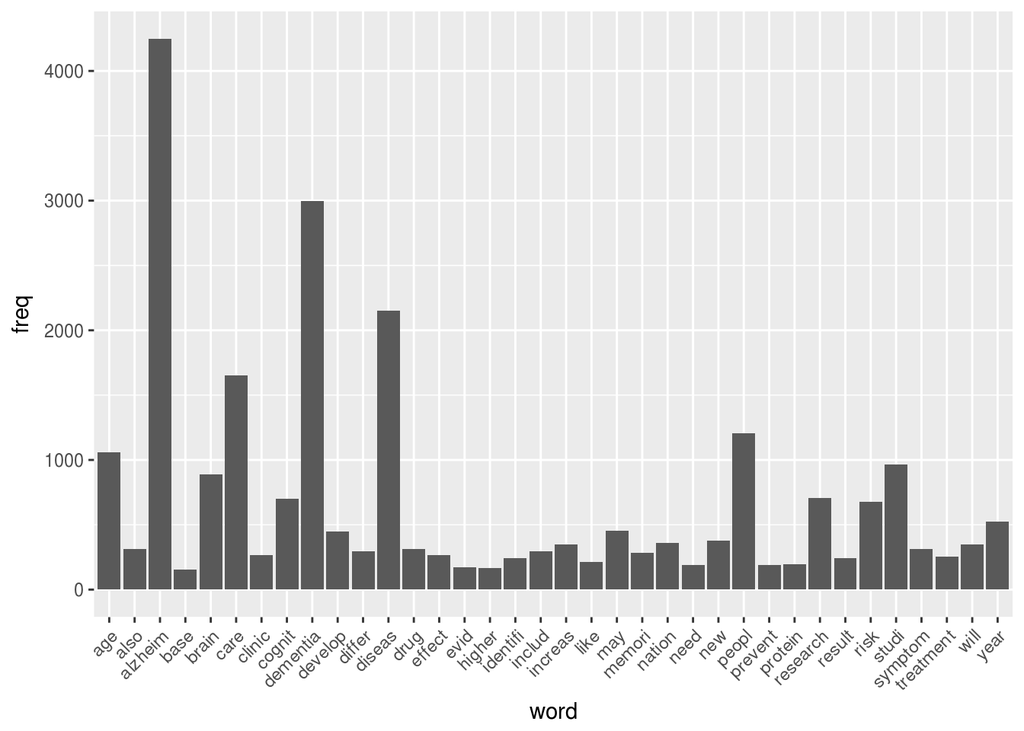

```r
library(ggplot2)
p <- ggplot(subset(wf, freq>150), aes(word, freq))
p <- p + geom_bar(stat="identity")
p <- p + theme(axis.text.x=element_text(angle=45, hjust=1))
p
```

Como se puede comprobar, los término relativos a Alzheimer, cuidados, demencia, enfermedad son los más frecuentes, y que nos da la misma información que la gráfica anterior pero con otra forma muy característica:

Por último podemos obtener una nube de palabras, muy atractiva visualmente con muy pocos comandos:

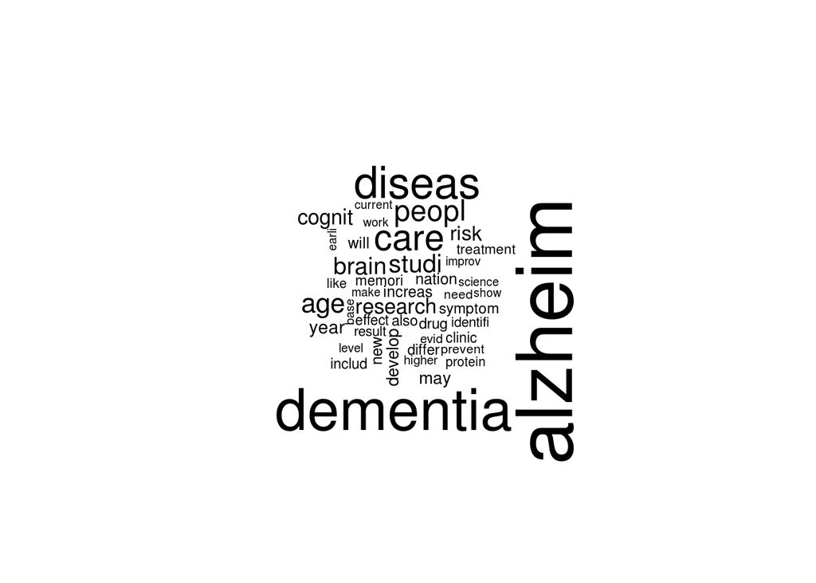

```r
library(wordcloud)
set.seed(234)
dark2 <- brewer.pal(6, "Dark2")
wordcloud(names(noSparseTermsFreq), noSparseTermsFreq, min.freq=125)
```

Se podrían sustituir estos términos por otros completos, esto es, por ejemplo *diseas* por *disease*, *alzheim* por *alzheimer*,*studi* por *study*, etc. Pero esto ya sabemos como realizarlo, se ha explicado anteriormente así que tan solo sería repetir el proceso para obtener al final las palabras deseadas.